# DATA607: TidyVerse

Farhana Akther

2023-04-04

#### TidyVerse Assignment: Collaborating Around a Code Project with GitHub.

## Overview

In this assignment we will get to practice collaborating around a code project with GitHub. We will create and example using one or more TidyVerse packages and demonstrate how to use the capabilities.

**We will use a birth dataset from ‘fivethirtyeight.com’. This dataset contains U.S. births data for 1994 - 2003 which, is provided by the Centers for Disease Control and Prevention’s (CDC’s) National Center for Health Statistics (NCNS). We will load the data from their GitHub repository.**

#### Load Library

```r
library(tidyverse)
```

```r
library(ggplot2)
```

## Load Data

```r
us_births <- read.csv("https://raw.githubusercontent.com/fivethirtyeight/data/master/births/US_births_1994-2003_CDC_NCHS.csv", header = TRUE)
```

#### Header Defination Table.

[figure not shown]

## View Data

*View the dataset*

```r
dim_desc(us_births)
```

```
## [1] "[3,652 x 5]"
```

```r
head(us_births)
```

```
##   year month date_of_month day_of_week births
## 1 1994     1             1           6   8096
## 2 1994     1             2           7   7772
## 3 1994     1             3           1  10142
## 4 1994     1             4           2  11248
## 5 1994     1             5           3  11053
## 6 1994     1             6           4  11406
```

```r
tail(us_births)
```

```
##      year month date_of_month day_of_week births
## 3647 2003    12            26           5  10218
## 3648 2003    12            27           6   8646
## 3649 2003    12            28           7   7645
## 3650 2003    12            29           1  12823
## 3651 2003    12            30           2  14438
## 3652 2003    12            31           3  12374
```

*there are 3652obs/rows and 5 variables/columns*

**Now, I will transform the dataset by using functions from the dplyr and ggplot package.**

## dplyr::summerize() & dplyr::sum()

**How many total number of births in the US from 1994-2003?**

```r
us_births %>% summarise(total_births = sum(births))
```

```
##   total_births
## 1     39722137
```

## dplyr::Groupby(), dplyr::summerize() & dplyr::sum()

**How many total number of births in the US from 1994-2003 each year?**

```r
Totalbirth<-us_births %>%
  group_by(year) %>%
  summarise(total_births = sum(births))
Totalbirth
```

```
## # A tibble: 10 × 2
##     year total_births
##    <int>        <int>
##  1  1994      3952767
##  2  1995      3899589
##  3  1996      3891494
##  4  1997      3880894
##  5  1998      3941553
##  6  1999      3959417
##  7  2000      4058814
##  8  2001      4025933
##  9  2002      4021726
## 10  2003      4089950
```

## ggplot2::ggplot()

**Showing in graph the total number of births in the US from 1994-2203 each year**

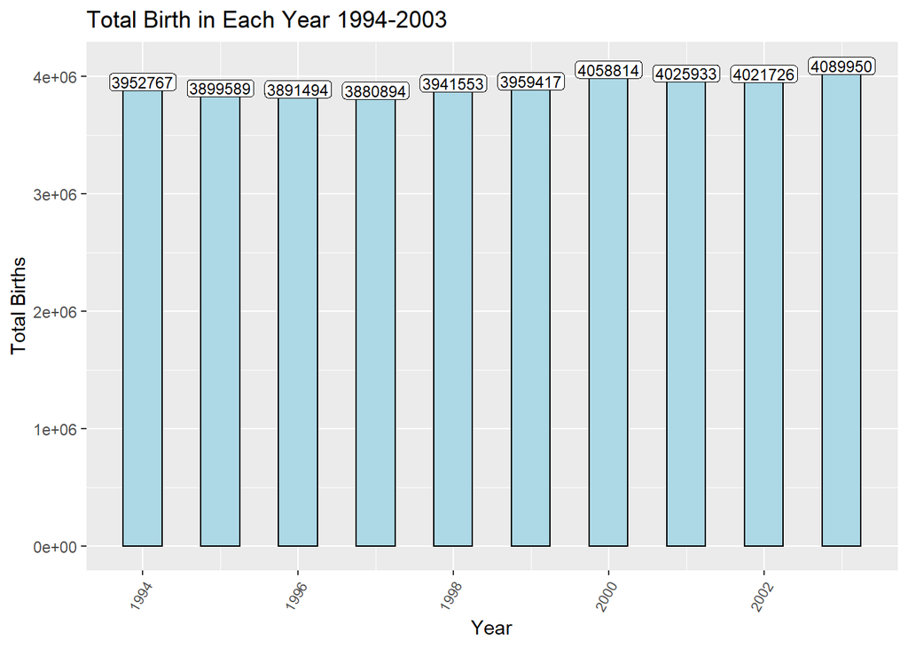

```r
ggplot(Totalbirth, aes(x=(year), total_births)) + geom_bar(stat="identity", width = 0.5, color = "black", fill = "lightblue") + labs(x = "Year", y = "Total Births", title = "Total Birth in Each Year 1994-2003") + theme(axis.text.x = element_text(angle = 60, hjust = 1, size=8)) + geom_label(aes(label=total_births), position = position_dodge(width = 0.1), size = 3, label.padding = unit(0.1, "lines"), label.size = 0.09, inherit.aes = TRUE)
```